# Model_Group22_AIP_Group_Assignment

This is to certify that the work I am submitting is my own. All external references and sources are clearly acknowledged and identified within the contents. I am aware of the University of Warwick regulation concerning plagiarism and collusion.

No substantial part(s) of the work submitted here has also been submitted by me in other assessments for accredited courses of study, and I acknowledge that if this has been done an appropriate reduction in the mark I might otherwise have received will be made.

# Data Dictionary

The variables of the dataset are described in the table below.

| Variables | Description |
| --- | --- |
| ID | customer identification number |
| Gender | gender of the customer |
| Age | age of the customer in years |
| Dependent | whether the customer has a dependent or not |
| Marital_Status | marital state (1=married, 2=single, 0 = others) |
| Region_Code | code of the region for the customer |
| Years_at_Residence | the duration in the current residence (in years) |
| Occupation | occupation type of the customer |
| Channel_Code | acquisition channel code used to reach the customer when they opened their bank account |
| Vintage | the number of months that the customer has been associated with the company. |
| Credit_Product | if the customer has any active credit product (home loan, personal loan, credit card etc.) |
| Avg_Account_Balance | average account balance for the customer in last 12 months |
| Account_Type | account type of the customer with categories Silver, Gold and Platinum |
| Active | if the customer is active in last 3 months |
| Registration | whether the customer has visited the bank for the offered product registration (1 = yes; 0 = no) |
| Target | whether the customer has purchased the product (1 = Customer did not purchase the product, 0= Customer purchased the product) |

# Data Preparation

## Importing essential libraries

```r
library(tidyverse)
library(FSelector)
library(caret)
library(C50)
library(gmodels)
library(randomForest)
library(e1071)
library(ROSE)
library(party)
library(modeldata)
library(rpart)
library(randomForestSRC)
library(pROC)
# Load mltools and data.table package for one-hot encoding
library(mltools)
library(data.table)
# Load dplyr package for data encoding
library(dplyr)
```

## Importing Data from csv. file

```r
mydata <- read.csv("assignment_data.csv" , stringsAsFactors = TRUE)

summary(mydata)
```

```
##        ID            Gender            Age          Dependent
##  Min.   :110001   Female:101483   Min.   :23.00   Min.   :-1.0000
##  1st Qu.:165001   Male  :118517   1st Qu.:29.00   1st Qu.: 0.0000
##  Median :220000                   Median :41.00   Median : 1.0000
##  Mean   :220000                   Mean   :43.14   Mean   : 0.5014
##  3rd Qu.:275000                   3rd Qu.:53.00   3rd Qu.: 1.0000
##  Max.   :330000                   Max.   :85.00   Max.   : 1.0000
##
##  Marital_Status    Region_Code    Years_at_Residence         Occupation
##  Min.   :0.0000   RG268  :31224   Min.   :1.000      Entrepreneur : 1891
##  1st Qu.:0.0000   RG283  :25508   1st Qu.:2.000      Other        :62558
##  Median :1.0000   RG254  :24247   Median :3.000      Salaried     :66911
##  Mean   :0.9787   RG284  :16806   Mean   :2.998      Self_Employed:88640
##  3rd Qu.:2.0000   RG277  :11512   3rd Qu.:4.000
##  Max.   :2.0000   RG280  :11421   Max.   :5.000
##                   (Other):99282
##  Channel_Code    Vintage       Credit_Product Avg_Account_Balance
##  X1:99530     Min.   :  7.00   No  :139660    Min.   :   20790
##  X2:57892     1st Qu.: 20.00   Yes : 62072    1st Qu.:  598131
##  X3:57646     Median : 32.00   NA's: 18268    Median :  885069
##  X4: 4932     Mean   : 45.06                  Mean   : 1118778
##               3rd Qu.: 68.00                  3rd Qu.: 1352472
##               Max.   :135.00                  Max.   :10352009
##
##    Account_Type   Active        Registration        Target
##  Gold    :73296   No :136513   Min.   :0.0000   Min.   :0.000
##  Platinum:73172   Yes: 83487   1st Qu.:0.0000   1st Qu.:0.000
##  Silver  :73532                Median :0.0000   Median :0.000
##                                Mean   :0.1235   Mean   :0.148
##                                3rd Qu.:0.0000   3rd Qu.:0.000
##                                Max.   :1.0000   Max.   :1.000
##
```

```r
str(mydata)
```

```
## 'data.frame':    220000 obs. of  16 variables:
##  $ ID                 : int  110001 110002 110003 110004 110005 110006 110007 110008 110009 110010 ...
##  $ Gender             : Factor w/ 2 levels "Female","Male": 1 1 1 2 1 2 1 1 1 2 ...
##  $ Age                : int  73 30 56 34 30 56 48 40 55 53 ...
##  $ Dependent          : int  0 1 0 0 1 1 0 1 0 1 ...
##  $ Marital_Status     : int  1 1 0 1 0 0 0 0 2 1 ...
##  $ Region_Code        : Factor w/ 35 levels "RG250","RG251",..: 19 28 19 21 33 12 16 34 19 5 ...
##  $ Years_at_Residence : int  1 1 3 5 3 2 2 4 5 5 ...
##  $ Occupation         : Factor w/ 4 levels "Entrepreneur",..: 2 3 4 3 3 4 4 4 4 4 ...
##  $ Channel_Code       : Factor w/ 4 levels "X1","X2","X3",..: 3 1 3 1 1 1 3 2 2 3 ...
##  $ Vintage            : int  43 32 26 19 33 32 13 38 49 88 ...
##  $ Credit_Product     : Factor w/ 2 levels "No","Yes": 1 1 1 1 1 1 1 1 2 1 ...
##  $ Avg_Account_Balance: int  1045696 581988 1484315 470454 886787 544163 444724 1274284 2014239 980664 ...
##  $ Account_Type       : Factor w/ 3 levels "Gold","Platinum",..: 1 1 3 3 1 1 3 1 1 2 ...
##  $ Active             : Factor w/ 2 levels "No","Yes": 1 1 2 1 1 2 2 1 1 2 ...
##  $ Registration       : int  0 0 0 0 0 0 0 0 0 0 ...
##  $ Target             : int  0 0 0 0 0 0 0 0 0 0 ...
```

## Checking correlation

```r
# extract numerical data, excluding ID column
numerical_data <- mydata[sapply(mydata, is.numeric) & names(mydata) != 'ID']

# compute correlation matrix
correlation_matrix <- cor(numerical_data)
print(correlation_matrix)
```

```
##                               Age     Dependent Marital_Status
## Age                  1.0000000000 -0.0005024263  -0.0628405313
## Dependent           -0.0005024263  1.0000000000   0.0000511522
## Marital_Status      -0.0628405313  0.0000511522   1.0000000000
## Years_at_Residence  -0.0006924336 -0.0029674083  -0.0007538974
## Vintage              0.6360700183  0.0004796966  -0.0286920456
## Avg_Account_Balance  0.1428894250  0.0009512555  -0.0068692478
## Registration         0.1079136427 -0.0014555892  -0.0035131964
## Target               0.1926044445 -0.0036987683  -0.0032068575
##                     Years_at_Residence       Vintage Avg_Account_Balance
## Age                      -0.0006924336  0.6360700183        0.1428894250
## Dependent                -0.0029674083  0.0004796966        0.0009512555
## Marital_Status           -0.0007538974 -0.0286920456       -0.0068692478
## Years_at_Residence        1.0000000000 -0.0011154831        0.0029103716
## Vintage                  -0.0011154831  1.0000000000        0.1621237171
## Avg_Account_Balance       0.0029103716  0.1621237171        1.0000000000
## Registration              0.0003675587  0.1314442330        0.0258782386
## Target                   -0.0004552870  0.2387373343        0.0444635935
##                      Registration       Target
## Age                  0.1079136427  0.192604445
## Dependent           -0.0014555892 -0.003698768
## Marital_Status      -0.0035131964 -0.003206858
## Years_at_Residence   0.0003675587 -0.000455287
## Vintage              0.1314442330  0.238737334
## Avg_Account_Balance  0.0258782386  0.044463593
## Registration         1.0000000000  0.540218620
## Target               0.5402186197  1.000000000
```

```r
# Removing ID Column
mydata$ID <- NULL

# Checking number of -1 values in 'Dependent' column
table(mydata$Dependent)
```

```
##
##     -1      0      1
##    118 109458 110424
```

```r
# Removing all the rows with -1 value in 'Dependent' column
mydata <- mydata %>% filter(!mydata$Dependent == -1)

# Checking number of -1 values after updation in 'Dependent' column
table(mydata$Dependent)
```

```
##
##      0      1
## 109458 110424
```

## Checking the NA values

```r
summarise_all(mydata, ~ sum(is.na(.x)))
```

```
##   Gender Age Dependent Marital_Status Region_Code Years_at_Residence Occupation
## 1      0   0         0              0           0                  0          0
##   Channel_Code Vintage Credit_Product Avg_Account_Balance Account_Type Active
## 1            0       0          18233                   0            0      0
##   Registration Target
## 1            0      0
```

```r
# There are 18233 NA items of Credit_Product
```

## Checking information gain of overall independent variables before removing the NA values from Credit_product

```r
# Set a seed
set.seed(123)

# Partition the dataset into training and test sets
# index keeps the record indices for the training data
index = createDataPartition(mydata$Credit_Product , p = 0.8, list = FALSE)

# Generate training and test data
training = mydata[index,]
test = mydata[-index,]
```

```r
# Use function information.gain to compute information gain values of the attributes
target <- information.gain(Target~., training)

# Print weights
print(target)
```

```
##                     attr_importance
## Gender                 1.312249e-03
## Age                    2.317544e-02
## Dependent              0.000000e+00
## Marital_Status         0.000000e+00
## Region_Code            4.313706e-03
## Years_at_Residence     0.000000e+00
## Occupation             5.987614e-03
## Channel_Code           2.273842e-02
## Vintage                2.445878e-02
## Credit_Product         8.987426e-02
## Avg_Account_Balance    1.375608e-03
## Account_Type           1.254884e-05
## Active                 1.720994e-03
## Registration           7.974004e-02
```

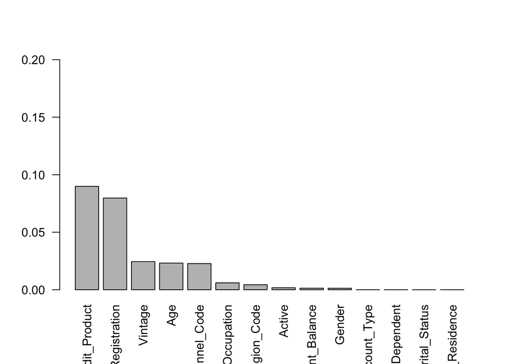

```r
# Add row names as a column to keep them during ordering
target$attr  <- rownames(target)

# Sort the weights in decreasing order of information gain values.
target <- arrange(target, -attr_importance)

# Plot the weights
barplot(target$attr_importance, names = target$attr, las = 2, ylim = c(0, 0.20))
```

```r
# The results show that Credit_Production variable is the important factor, so we decided to build a model to predict NA values of the Credit_Product
```

## Checking the imbalance of “Credit_Product”

```r
summary(mydata$Credit_Product)
```

```
##     No    Yes   NA's
## 139622  62027  18233
```

```r
prop.table(table(mydata$Credit_Product))
```

```
##
##        No       Yes
## 0.6924012 0.3075988
```

```r
# New table with no NA values
# Removing the NA values and assigning it to new variable for model buildin
modeling_data <- na.omit(mydata)

# Set a seed
set.seed(123)

# Partition the dataset into training and test sets
# index keeps the record indices for the training data
index = createDataPartition(modeling_data$Credit_Product , p = 0.7, list = FALSE)

# Generate training and test data
training = modeling_data[index,]
test = modeling_data[-index,]

str(modeling_data)
```

```
## 'data.frame':    201649 obs. of  15 variables:
##  $ Gender             : Factor w/ 2 levels "Female","Male": 1 1 1 2 1 2 1 1 1 2 ...
##  $ Age                : int  73 30 56 34 30 56 48 40 55 53 ...
##  $ Dependent          : int  0 1 0 0 1 1 0 1 0 1 ...
##  $ Marital_Status     : int  1 1 0 1 0 0 0 0 2 1 ...
##  $ Region_Code        : Factor w/ 35 levels "RG250","RG251",..: 19 28 19 21 33 12 16 34 19 5 ...
##  $ Years_at_Residence : int  1 1 3 5 3 2 2 4 5 5 ...
##  $ Occupation         : Factor w/ 4 levels "Entrepreneur",..: 2 3 4 3 3 4 4 4 4 4 ...
##  $ Channel_Code       : Factor w/ 4 levels "X1","X2","X3",..: 3 1 3 1 1 1 3 2 2 3 ...
##  $ Vintage            : int  43 32 26 19 33 32 13 38 49 88 ...
##  $ Credit_Product     : Factor w/ 2 levels "No","Yes": 1 1 1 1 1 1 1 1 2 1 ...
##  $ Avg_Account_Balance: int  1045696 581988 1484315 470454 886787 544163 444724 1274284 2014239 980664 ...
##  $ Account_Type       : Factor w/ 3 levels "Gold","Platinum",..: 1 1 3 3 1 1 3 1 1 2 ...
##  $ Active             : Factor w/ 2 levels "No","Yes": 1 1 2 1 1 2 2 1 1 2 ...
##  $ Registration       : int  0 0 0 0 0 0 0 0 0 0 ...
##  $ Target             : int  0 0 0 0 0 0 0 0 0 0 ...
##  - attr(*, "na.action")= 'omit' Named int [1:18233] 99 215 216 235 274 392 494 552 743 747 ...
##   ..- attr(*, "names")= chr [1:18233] "99" "215" "216" "235" ...
```

## Checking the information gain from each rows for the column “Credit_Product” and plotting it

```r
credit <- information.gain(Credit_Product~., training)
print(credit)
```

```
##                     attr_importance
## Gender                 1.702660e-03
## Age                    2.746191e-02
## Dependent              0.000000e+00
## Marital_Status         0.000000e+00
## Region_Code            9.754004e-03
## Years_at_Residence     0.000000e+00
## Occupation             1.841596e-02
## Channel_Code           3.064579e-02
## Vintage                1.774894e-02
## Avg_Account_Balance    3.828864e-03
## Account_Type           9.753826e-06
## Active                 7.538588e-03
## Registration           8.138060e-03
## Target                 3.031281e-02
```

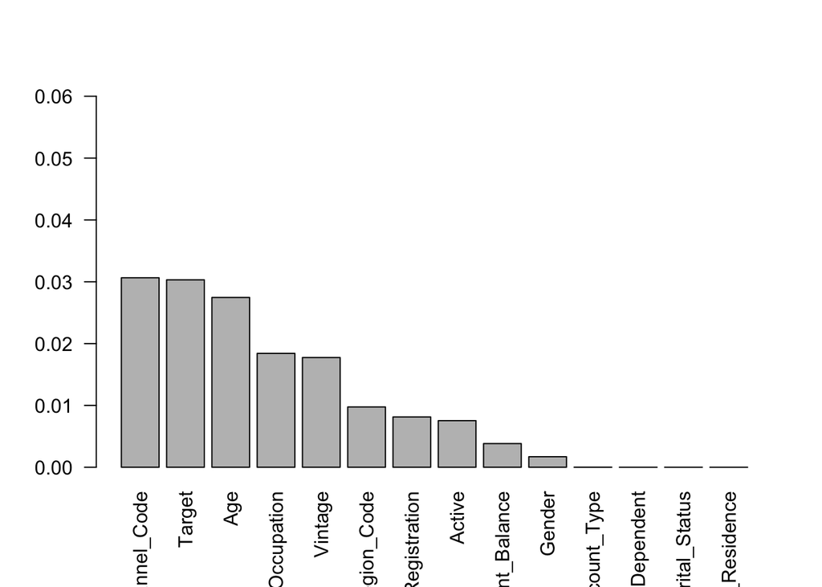

```r
# Add row names as a column to keep them during ordering
credit$attr  <- rownames(credit)

# Let's sort the weights in decreasing order of information gain values.
# We will use arrange() function
credit <- arrange(credit, -attr_importance)

# Plot the weights
barplot(credit$attr_importance, names = credit$attr, las = 2, ylim = c(0, 0.06))
```

```r
# Saving the names of the column in 'features' variable with information gain > 0
# features <- filter(credit, attr_importance > 0)$attr
# print(features)
```

# Building a model to predict the “Credit_Product” value

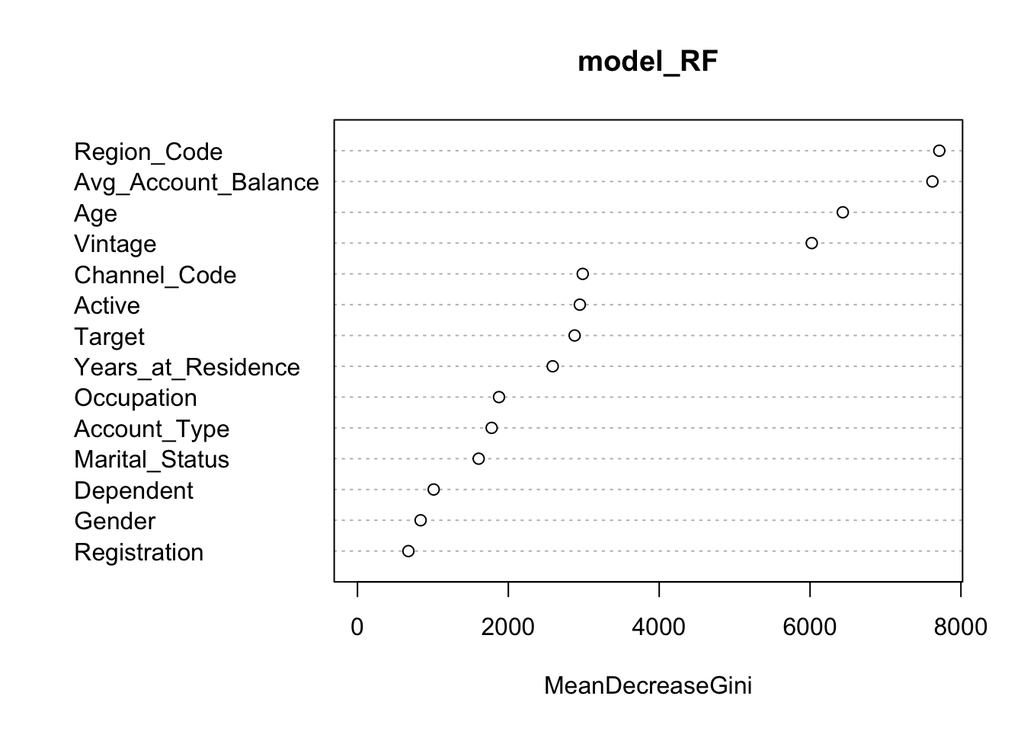

```r
datamodelling <- training

# Adding 'Credit_Product' to our filtered features
# datamodelling$Credit_Product <- training$Credit_Product

# Removing the 'Gender' and 'Registration'
datamodelling$ID <- NULL
# datamodelling$Registration <- NULL
# datamodelling$Gender <- NULL
# datamodelling$Region_Code <- NULL

# Build Random Forest model
model_RF <- randomForest(Credit_Product ~., datamodelling)

# Plot the importance values
varImpPlot(model_RF)
```

```r
# model_RF prediction
prediction_RF <- predict(model_RF, test)

# Compute the confusion matrix
confusionMatrix(data = prediction_RF, test$Credit_Product, mode = "prec_recall")
```

```
## Confusion Matrix and Statistics
##
##           Reference
## Prediction    No   Yes
##        No  38154 10720
##        Yes  3732  7888
##
##                Accuracy : 0.7611
##                  95% CI : (0.7577, 0.7645)
##     No Information Rate : 0.6924
##     P-Value [Acc > NIR] : < 2.2e-16
##
##                   Kappa : 0.3738
##
##  Mcnemar's Test P-Value : < 2.2e-16
##
##               Precision : 0.7807
##                  Recall : 0.9109
##                      F1 : 0.8408
##              Prevalence : 0.6924
##          Detection Rate : 0.6307
##    Detection Prevalence : 0.8079
##       Balanced Accuracy : 0.6674
##
##        'Positive' Class : No
##
```

```r
#dataset with NA values
temp <- mydata[!complete.cases(mydata), ]

pred_temp <- predict(model_RF, temp)

temp$pred_Credit_Product <- pred_temp

summary(temp)
```

```
##     Gender           Age         Dependent      Marital_Status    Region_Code
##  Female: 6878   Min.   :24.0   Min.   :0.0000   Min.   :0.0000   RG268  :3502
##  Male  :11355   1st Qu.:44.0   1st Qu.:0.0000   1st Qu.:0.0000   RG283  :2941
##                 Median :51.0   Median :0.0000   Median :1.0000   RG284  :1882
##                 Mean   :51.7   Mean   :0.4979   Mean   :0.9664   RG254  :1694
##                 3rd Qu.:58.0   3rd Qu.:1.0000   3rd Qu.:2.0000   RG277  : 923
##                 Max.   :85.0   Max.   :1.0000   Max.   :2.0000   RG280  : 907
##                                                                  (Other):6384
##  Years_at_Residence         Occupation   Channel_Code    Vintage
##  Min.   :1.000      Entrepreneur : 630   X1:1901      Min.   :  7.00
##  1st Qu.:2.000      Other        :5845   X2:7304      1st Qu.: 31.00
##  Median :3.000      Salaried     :2509   X3:8611      Median : 75.00
##  Mean   :3.008      Self_Employed:9249   X4: 417      Mean   : 66.81
##  3rd Qu.:4.000                                        3rd Qu.: 93.00
##  Max.   :5.000                                        Max.   :135.00
##
##  Credit_Product Avg_Account_Balance   Account_Type  Active      Registration
##  No  :    0     Min.   :  50293     Gold    :6134   No :9679   Min.   :0.0000
##  Yes :    0     1st Qu.: 675127     Platinum:6037   Yes:8554   1st Qu.:0.0000
##  NA's:18233     Median :1005993     Silver  :6062              Median :0.0000
##                 Mean   :1228682                                Mean   :0.4305
##                 3rd Qu.:1508096                                3rd Qu.:1.0000
##                 Max.   :9147881                                Max.   :1.0000
##
##      Target       pred_Credit_Product
##  Min.   :0.0000   No : 3902
##  1st Qu.:1.0000   Yes:14331
##  Median :1.0000
##  Mean   :0.7614
##  3rd Qu.:1.0000
##  Max.   :1.0000
##
```

```r
## modeling_data -  Contains all the non-NA values
## temp - Contains all the predicted NA values
# dataset with NA values
temp <- mydata[!complete.cases(mydata), ]

# predicting NA values for 'temp' dataset
prediction_RF_1 <- predict(model_RF, temp)

# assigning the predicted values to the 'Credit_Product' column
temp$Credit_Product <- prediction_RF_1

# prop.table(table(temp$Credit_Product))
```

## Merged dataset - ‘final_ds’

```r
# Final dataset with all the no NA values - 'final_ds'
final_ds <- rbind(modeling_data, temp)
# Final dataset predicted NA values (76% acc)

summary(final_ds$Credit_Product)
```

```
##     No    Yes
## 143524  76358
```

```r
prop.table(table(final_ds$Credit_Product))
```

```
##
##        No       Yes
## 0.6527319 0.3472681
```

```r
summarise_all(final_ds, ~ sum(is.na(.x)))
```

```
##   Gender Age Dependent Marital_Status Region_Code Years_at_Residence Occupation
## 1      0   0         0              0           0                  0          0
##   Channel_Code Vintage Credit_Product Avg_Account_Balance Account_Type Active
## 1            0       0              0                   0            0      0
##   Registration Target
## 1            0      0
```

```r
summary(final_ds$Target)
```

```
##    Min. 1st Qu.  Median    Mean 3rd Qu.    Max.
##  0.0000  0.0000  0.0000  0.1477  0.0000  1.0000
```

```r
prop.table(table(final_ds$Target))
```

```
##
##         0         1
## 0.8523071 0.1476929
```

## Updating type of cleaning data

```r
final_ds$Target <- as.factor(final_ds$Target)
final_ds$Dependent <- as.factor(final_ds$Dependent)
final_ds$Registration <- as.factor(final_ds$Registration)
final_ds$Marital_Status <- as.factor(final_ds$Marital_Status)
```

## Checking the imbalance data of Target columns and data partition

```r
# Set a seed
set.seed(123)

# Partition the dataset into training and test sets
# index keeps the record indices for the training data
index = createDataPartition(final_ds$Target , p = 0.7, list = FALSE)

# Generate training and test data
training_DT = final_ds[index,]
test_DT = final_ds[-index,]
```

```r
# Check the class distribution in the target column for final_ds, trainingset and testset

table(final_ds$Target)
```

```
##
##      0      1
## 187407  32475
```

```r
table(training_DT$Target)
```

```
##
##      0      1
## 131185  22733
```

```r
table(test_DT$Target)
```

```
##
##     0     1
## 56222  9742
```

```r
prop.table(table(final_ds$Target))
```

```
##
##         0         1
## 0.8523071 0.1476929
```

```r
prop.table(table(training_DT$Target))
```

```
##
##         0         1
## 0.8523045 0.1476955
```

```r
prop.table(table(test_DT$Target))
```

```
##
##         0         1
## 0.8523134 0.1476866
```

```r
# the table showed there is necessary to balance the dataset (final_ds)
```

## Applying three techniques to deal with imbalanced dataset

```r
# Apply oversampling technique
oversampled <- ovun.sample(Target~. , data = training_DT, method = "over", p=0.4,seed=1)$data
```

Results from the oversampled training set:

```r
# Check the distribution of Target in the oversampled data
table(oversampled$Target)
```

```
##
##      0      1
## 131185  87651
```

```r
# Check the proportion of Target in the oversampled data
prop.table(table(oversampled$Target))
```

```
##
##         0         1
## 0.5994672 0.4005328
```

```r
# Apply undersampling technique
undersampled <- ovun.sample(Target~. , data = training_DT, method = "under", p=0.4,seed=1)$data
```

Results from the undersampled training set:

```r
# Check the distribution of Target in the oversampled data
table(undersampled$Target)
```

```
##
##     0     1
## 34077 22733
```

```r
# Check the proportion of Target in the oversampled data
prop.table(table(undersampled$Target))
```

```
##
##         0         1
## 0.5998416 0.4001584
```

```r
# Apply bothampling technique
bothsampled <- ovun.sample(Target~. , data = training_DT, method = "both", p=0.4,seed=1)$data
```

Results from the bothsampled training set:

```r
# Check the distribution of Target in the oversampled data
table(bothsampled$Target)
```

```
##
##     0     1
## 92337 61581
```

```r
# Check the proportion of Target in the oversampled data
prop.table(table(bothsampled$Target))
```

```
##
##         0         1
## 0.5999103 0.4000897
```

# Building the main models

## Building decision tree models

```r
# Build the decision tree and save it as tree_model
tree_model_origin <- C5.0(Target~., training_DT)
tree_model_over <- C5.0(Target~., oversampled)
tree_model_under <- C5.0(Target~., undersampled)
tree_model_both <- C5.0(Target~., bothsampled)
```

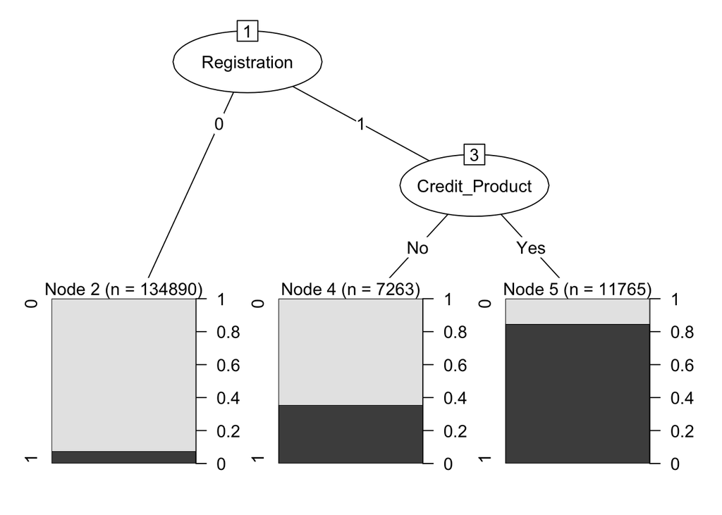

```r
# Build another decision tree with Credit_Product and Registration just for the purpose of illustration
tree_illustration_origin <- C5.0(Target~Credit_Product+Registration, training_DT)
tree_illustration_over <- C5.0(Target~Credit_Product+Registration, oversampled)
tree_illustration_under <- C5.0(Target~Credit_Product+Registration, undersampled)
tree_illustration_both <- C5.0(Target~Credit_Product+Registration, bothsampled)

# Plot the decision tree
plot(tree_illustration_origin)
```

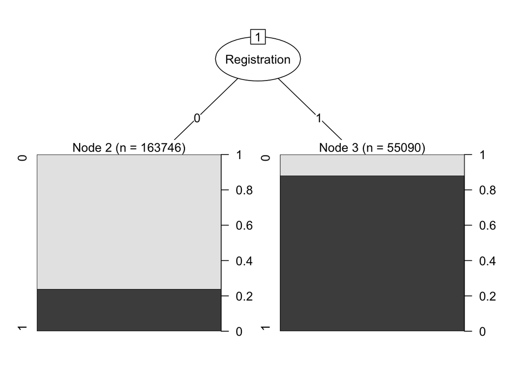

```r
plot(tree_illustration_over)
```

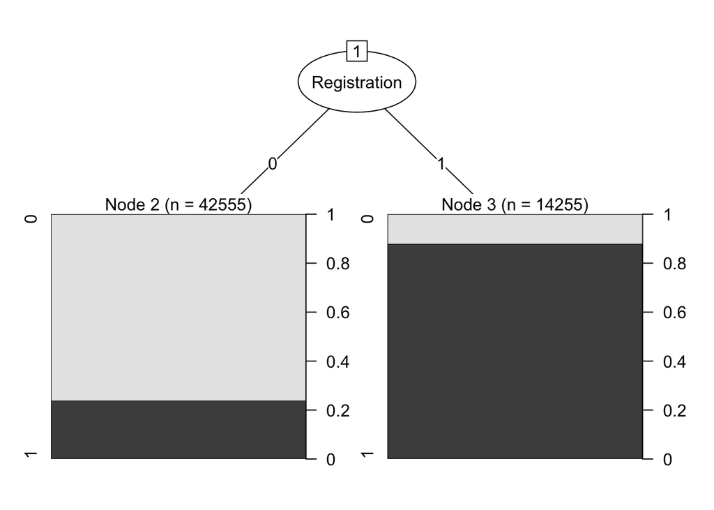

```r
plot(tree_illustration_under)
```

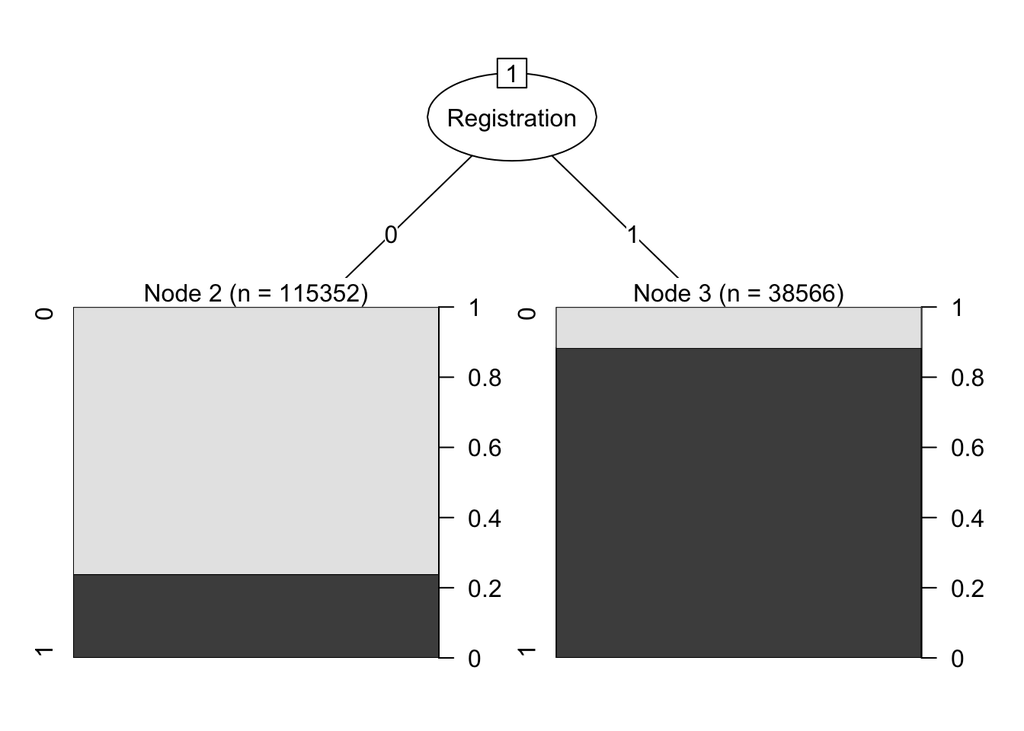

```r
plot(tree_illustration_both)
```

### Evaluation of decision tree models

```r
# Predicting the Test set results
tree_predict_origin = predict(tree_model_origin, test_DT, type= "class")
tree_predict_over = predict(tree_model_over, test_DT, type= "class")
tree_predict_under = predict(tree_model_under, test_DT, type= "class")
tree_predict_both = predict(tree_model_both, test_DT, type= "class")

# Total number of correct predictions
correct_tree_origin <- which(tree_predict_origin == test_DT$Target)
correct_tree_over <- which(tree_predict_over == test_DT$Target)
correct_tree_under <- which(tree_predict_under == test_DT$Target)
correct_tree_both <- which(tree_predict_both == test_DT$Target)

# Find the percentage of correct predictions
accuracy_tree_origin <- length(correct_tree_origin) / nrow(test_DT)
accuracy_tree_over <- length(correct_tree_over) / nrow(test_DT)
accuracy_tree_under <- length(correct_tree_under) / nrow(test_DT)
accuracy_tree_both <- length(correct_tree_both) / nrow(test_DT)
```

### Finding AUC

```r
#build decision tree models
tree.origin <- rpart(Target ~ ., data = training_DT)
tree.over <- rpart(Target ~ ., data = oversampled)
tree.under <- rpart(Target ~., data = undersampled)
tree.both <- rpart(Target ~ ., data = bothsampled)
```

```r
#make predictions on unseen data
pred.tree.origin <- predict(tree.origin, newdata = test_DT)
pred.tree.over <- predict(tree.over, newdata = test_DT)
pred.tree.under <- predict(tree.under, newdata = test_DT)
pred.tree.both <- predict(tree.both, newdata = test_DT)
```

### Finding accuracy

```r
accuracy.meas(test_DT$Target, pred.tree.origin[,2])
```

```
##
## Call:
## accuracy.meas(response = test_DT$Target, predicted = pred.tree.origin[,
##     2])
##
## Examples are labelled as positive when predicted is greater than 0.5
##
## precision: 0.837
## recall: 0.439
## F: 0.288
```

```r
accuracy.meas(test_DT$Target, pred.tree.over[,2])
```

```
##
## Call:
## accuracy.meas(response = test_DT$Target, predicted = pred.tree.over[,
##     2])
##
## Examples are labelled as positive when predicted is greater than 0.5
##
## precision: 0.498
## recall: 0.803
## F: 0.307
```

```r
accuracy.meas(test_DT$Target, pred.tree.under[,2])
```

```
##
## Call:
## accuracy.meas(response = test_DT$Target, predicted = pred.tree.under[,
##     2])
##
## Examples are labelled as positive when predicted is greater than 0.5
##
## precision: 0.492
## recall: 0.809
## F: 0.306
```

```r
accuracy.meas(test_DT$Target, pred.tree.both[,2])
```

```
##
## Call:
## accuracy.meas(response = test_DT$Target, predicted = pred.tree.both[,
##     2])
##
## Examples are labelled as positive when predicted is greater than 0.5
##
## precision: 0.492
## recall: 0.809
## F: 0.306
```

### Finding ROC

```r
# Use roc function to return some performance metrics
ROC_DT <- roc(test_DT$Target, pred.tree.origin[,2])
ROC_DT_over <- roc(test_DT$Target, pred.tree.over[,2])
ROC_DT_under <- roc(test_DT$Target, pred.tree.under[,2])
ROC_DT_both <- roc(test_DT$Target, pred.tree.both[,2])
```

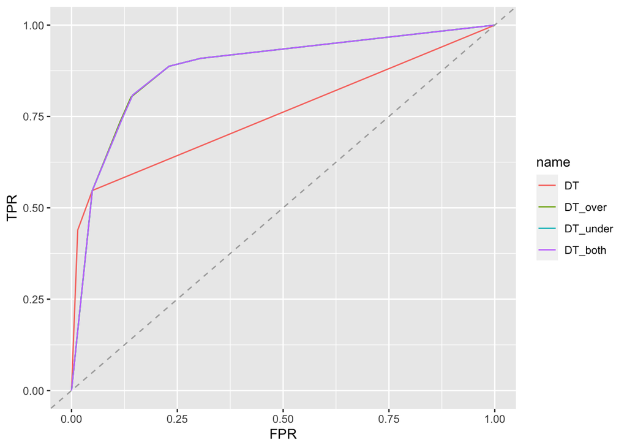

```r
# Plot the ROC curve for Decision Tree
ggroc(list(DT = ROC_DT, DT_over = ROC_DT_over, DT_under = ROC_DT_under, DT_both = ROC_DT_both), legacy.axes=TRUE)+ xlab("FPR") + ylab("TPR") + geom_abline(intercept = 0, slope = 1, color = "darkgrey", linetype = "dashed")
```

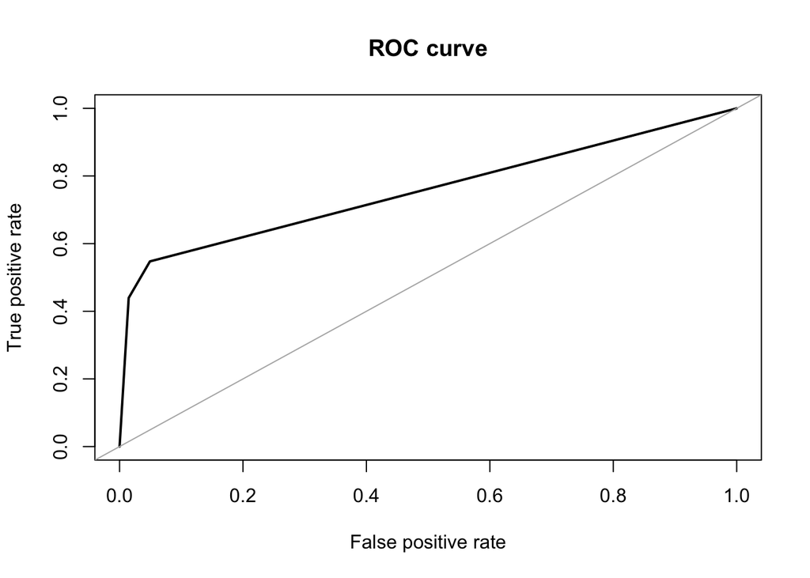

```
## Area under the curve (AUC): 0.756
```

```r
#AUC Origin
roc.curve(test_DT$Target, pred.tree.origin[,2])
```

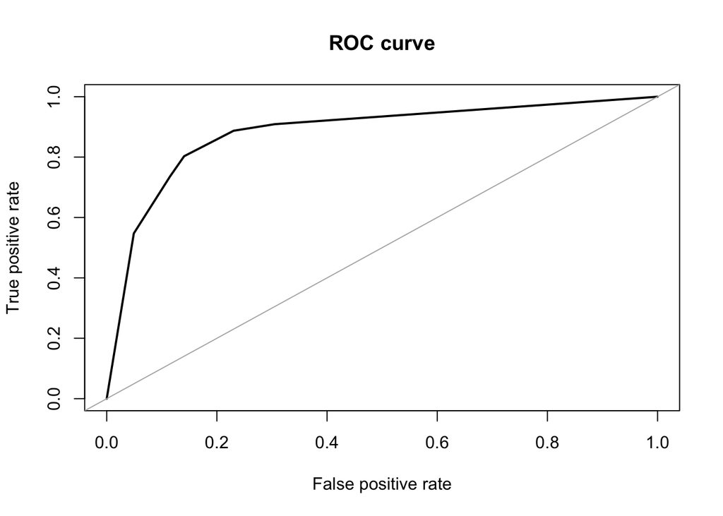

```
## Area under the curve (AUC): 0.882
```

```r
#AUC Oversampling
roc.curve(test_DT$Target, pred.tree.over[,2])
```

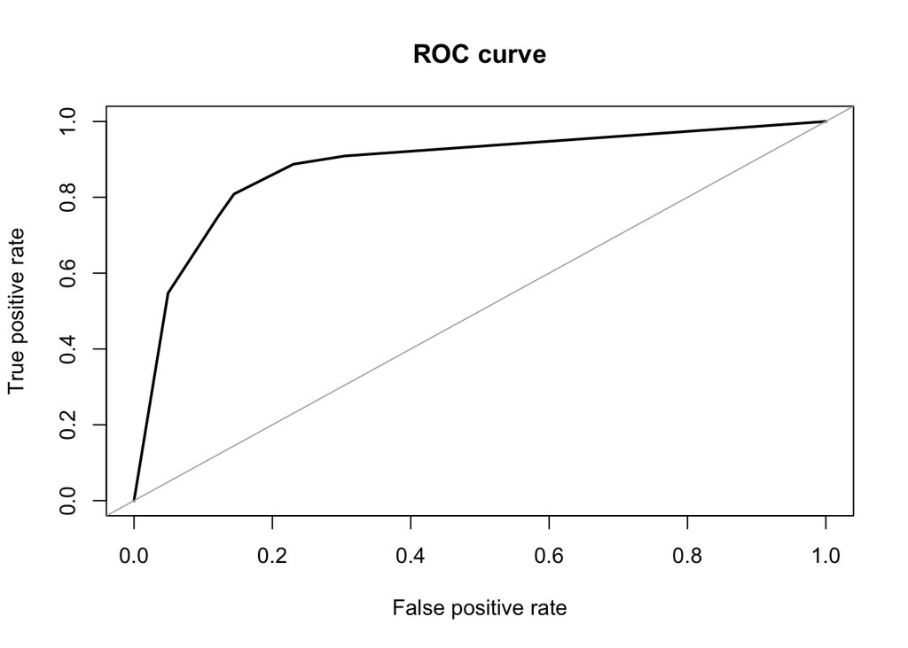

```
## Area under the curve (AUC): 0.881
```

```r
#AUC Undersampling
roc.curve(test_DT$Target, pred.tree.under[,2])
```

```r
#AUC Both
roc.curve(test_DT$Target, pred.tree.both[,2])
```

[output not shown]

```
## Area under the curve (AUC): 0.881
```

## Building random forest models

```r
set.seed(1)

# Build Random Forest model and assign it to model_RF
model_RFM <- randomForest(Target~., training_DT)
model_RF_over <- randomForest(Target~., oversampled)
model_RF_under <- randomForest(Target~., undersampled)
model_RF_both <- randomForest(Target~., bothsampled)


# Print model_RF models
print(model_RFM)
```

```
##
## Call:
##  randomForest(formula = Target ~ ., data = training_DT)
##                Type of random forest: classification
##                      Number of trees: 500
## No. of variables tried at each split: 3
##
##         OOB estimate of  error rate: 8.78%
## Confusion matrix:
##        0     1 class.error
## 0 128577  2608  0.01988032
## 1  10909 11824  0.47987507
```

```r
print(model_RF_over)
```

```
##
## Call:
##  randomForest(formula = Target ~ ., data = oversampled)
##                Type of random forest: classification
##                      Number of trees: 500
## No. of variables tried at each split: 3
##
##         OOB estimate of  error rate: 4.73%
## Confusion matrix:
##        0     1 class.error
## 0 122459  8726  0.06651675
## 1   1619 86032  0.01847098
```

```r
print(model_RF_under)
```

```
##
## Call:
##  randomForest(formula = Target ~ ., data = undersampled)
##                Type of random forest: classification
##                      Number of trees: 500
## No. of variables tried at each split: 3
##
##         OOB estimate of  error rate: 16.18%
## Confusion matrix:
##       0     1 class.error
## 0 29111  4966   0.1457288
## 1  4224 18509   0.1858092
```

```r
print(model_RF_both)
```

```
##
## Call:
##  randomForest(formula = Target ~ ., data = bothsampled)
##                Type of random forest: classification
##                      Number of trees: 500
## No. of variables tried at each split: 3
##
##         OOB estimate of  error rate: 4.38%
## Confusion matrix:
##       0     1 class.error
## 0 87651  4686  0.05074889
## 1  2052 59529  0.03332197
```

```r
# Check the important attributes by using importance() function
importance(model_RFM)
```

```
##                     MeanDecreaseGini
## Gender                      404.8903
## Age                        3453.6502
## Dependent                   457.0765
## Marital_Status              796.2953
## Region_Code                3425.6930
## Years_at_Residence         1222.4649
## Occupation                 1370.6049
## Channel_Code               1213.7557
## Vintage                    3619.2022
## Credit_Product             4146.3415
## Avg_Account_Balance        3516.9126
## Account_Type                834.6289
## Active                      529.2311
## Registration               9395.7377
```

```r
importance(model_RF_over)
```

```
##                     MeanDecreaseGini
## Gender                      967.0422
## Age                        9475.5083
## Dependent                  1076.5269
## Marital_Status             1869.4830
## Region_Code                8606.3411
## Years_at_Residence         2864.2056
## Occupation                 2725.1086
## Channel_Code               4719.8974
## Vintage                    9973.5292
## Credit_Product            16646.7785
## Avg_Account_Balance        8235.9632
## Account_Type               1994.6646
## Active                     1414.8166
## Registration              23844.8500
```

```r
importance(model_RF_under)
```

```
##                     MeanDecreaseGini
## Gender                      267.0333
## Age                        2663.5812
## Dependent                   296.2856
## Marital_Status              529.3557
## Region_Code                2406.9767
## Years_at_Residence          801.8139
## Occupation                  742.4980
## Channel_Code               1262.5567
## Vintage                    2545.0832
## Credit_Product             4286.5038
## Avg_Account_Balance        2150.8852
## Account_Type                546.8340
## Active                      361.6841
## Registration               6138.5999
```

```r
importance(model_RF_both)
```

```
##                     MeanDecreaseGini
## Gender                      693.3247
## Age                        7063.8276
## Dependent                   771.9208
## Marital_Status             1362.1016
## Region_Code                6202.7379
## Years_at_Residence         2071.5325
## Occupation                 1978.4056
## Channel_Code               3494.9535
## Vintage                    6808.8921
## Credit_Product            11607.2322
## Avg_Account_Balance        5769.6048
## Account_Type               1455.5889
## Active                      972.5391
## Registration              16897.6056
```

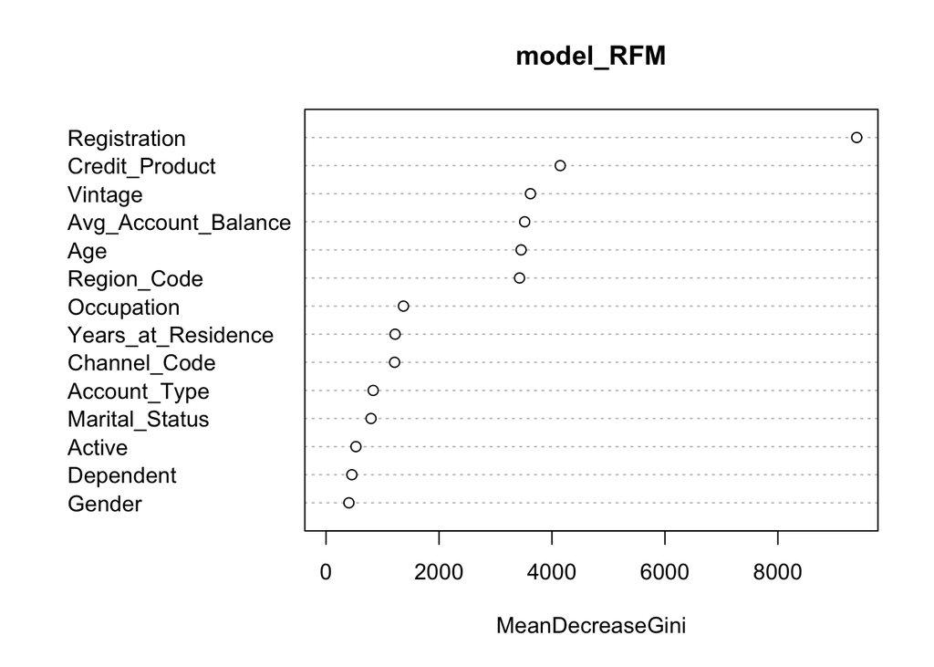

```r
# Plot the importance values
varImpPlot(model_RFM)
```

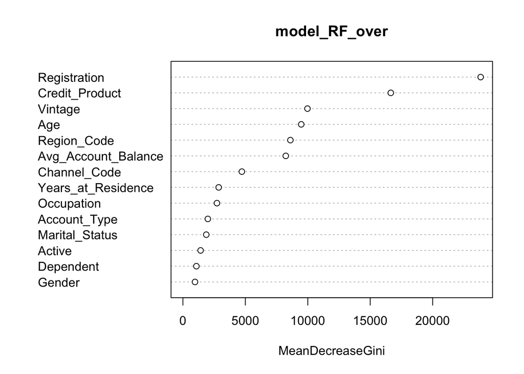

```r
varImpPlot(model_RF_over)
```

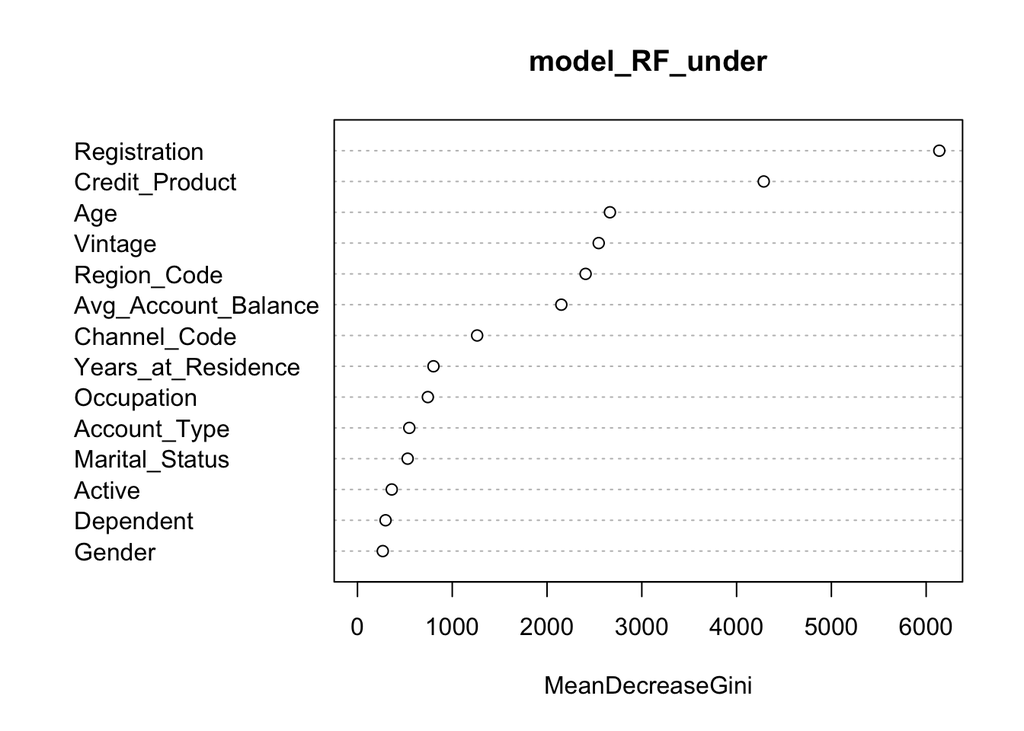

```r
varImpPlot(model_RF_under)
```

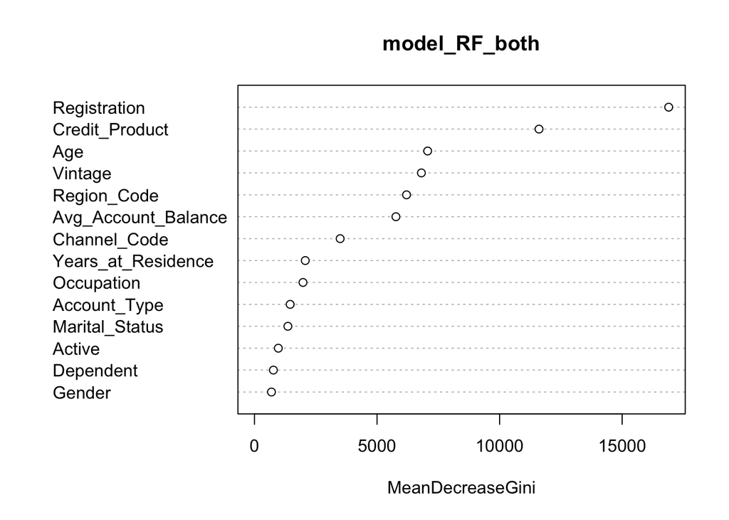

```r
varImpPlot(model_RF_both)
```

### Evaluation of Random Forest Model before tuning models

```r
# Using model_RF predict the class of the test data
prediction_RFM <- predict(model_RFM, test_DT)
prediction_RF_over <- predict(model_RF_over, test_DT)
prediction_RF_under <- predict(model_RF_under, test_DT)
prediction_RF_both <- predict(model_RF_both, test_DT)
```

```r
prob_RFM <- predict(model_RFM, test_DT, type = "prob")
prob_RF_over <- predict(model_RF_over, test_DT, type = "prob")
prob_RF_under <- predict(model_RF_under, test_DT, type = "prob")
prob_RF_both <- predict(model_RF_both, test_DT, type = "prob")
```

```r
# Compute the confusion matrix
confusionMatrix(prediction_RFM, test_DT$Target, positive='1', mode = "prec_recall")
```

```
## Confusion Matrix and Statistics
##
##           Reference
## Prediction     0     1
##          0 55090  4745
##          1  1132  4997
##
##                Accuracy : 0.9109
##                  95% CI : (0.9087, 0.9131)
##     No Information Rate : 0.8523
##     P-Value [Acc > NIR] : < 2.2e-16
##
##                   Kappa : 0.582
##
##  Mcnemar's Test P-Value : < 2.2e-16
##
##               Precision : 0.81530
##                  Recall : 0.51293
##                      F1 : 0.62970
##              Prevalence : 0.14769
##          Detection Rate : 0.07575
##    Detection Prevalence : 0.09291
##       Balanced Accuracy : 0.74640
##
##        'Positive' Class : 1
##
```

```r
confusionMatrix(prediction_RF_over, test_DT$Target, positive='1', mode = "prec_recall")
```

```
## Confusion Matrix and Statistics
##
##           Reference
## Prediction     0     1
##          0 52577  3272
##          1  3645  6470
##
##                Accuracy : 0.8951
##                  95% CI : (0.8928, 0.8975)
##     No Information Rate : 0.8523
##     P-Value [Acc > NIR] : < 2.2e-16
##
##                   Kappa : 0.59
##
##  Mcnemar's Test P-Value : 7.718e-06
##
##               Precision : 0.63964
##                  Recall : 0.66413
##                      F1 : 0.65166
##              Prevalence : 0.14769
##          Detection Rate : 0.09808
##    Detection Prevalence : 0.15334
##       Balanced Accuracy : 0.79965
##
##        'Positive' Class : 1
##
```

```r
confusionMatrix(prediction_RF_under, test_DT$Target, positive='1', mode = "prec_recall")
```

```
## Confusion Matrix and Statistics
##
##           Reference
## Prediction     0     1
##          0 48102  1790
##          1  8120  7952
##
##                Accuracy : 0.8498
##                  95% CI : (0.847, 0.8525)
##     No Information Rate : 0.8523
##     P-Value [Acc > NIR] : 0.9676
##
##                   Kappa : 0.5296
##
##  Mcnemar's Test P-Value : <2e-16
##
##               Precision : 0.4948
##                  Recall : 0.8163
##                      F1 : 0.6161
##              Prevalence : 0.1477
##          Detection Rate : 0.1206
##    Detection Prevalence : 0.2436
##       Balanced Accuracy : 0.8359
##
##        'Positive' Class : 1
##
```

```r
confusionMatrix(prediction_RF_both, test_DT$Target, positive='1', mode = "prec_recall")
```

```
## Confusion Matrix and Statistics
##
##           Reference
## Prediction     0     1
##          0 50599  2471
##          1  5623  7271
##
##                Accuracy : 0.8773
##                  95% CI : (0.8748, 0.8798)
##     No Information Rate : 0.8523
##     P-Value [Acc > NIR] : < 2.2e-16
##
##                   Kappa : 0.5701
##
##  Mcnemar's Test P-Value : < 2.2e-16
##
##               Precision : 0.5639
##                  Recall : 0.7464
##                      F1 : 0.6424
##              Prevalence : 0.1477
##          Detection Rate : 0.1102
##    Detection Prevalence : 0.1955
##       Balanced Accuracy : 0.8232
##
##        'Positive' Class : 1
##
```

```r
# Use roc function to return some performance metrics
ROC_RFM <- roc(test_DT$Target, prob_RFM[,2])
ROC_RF_over <- roc(test_DT$Target, prob_RF_over[,2])
ROC_RF_under <- roc(test_DT$Target, prob_RF_under[,2])
ROC_RF_both <- roc(test_DT$Target, prob_RF_both[,2])
```

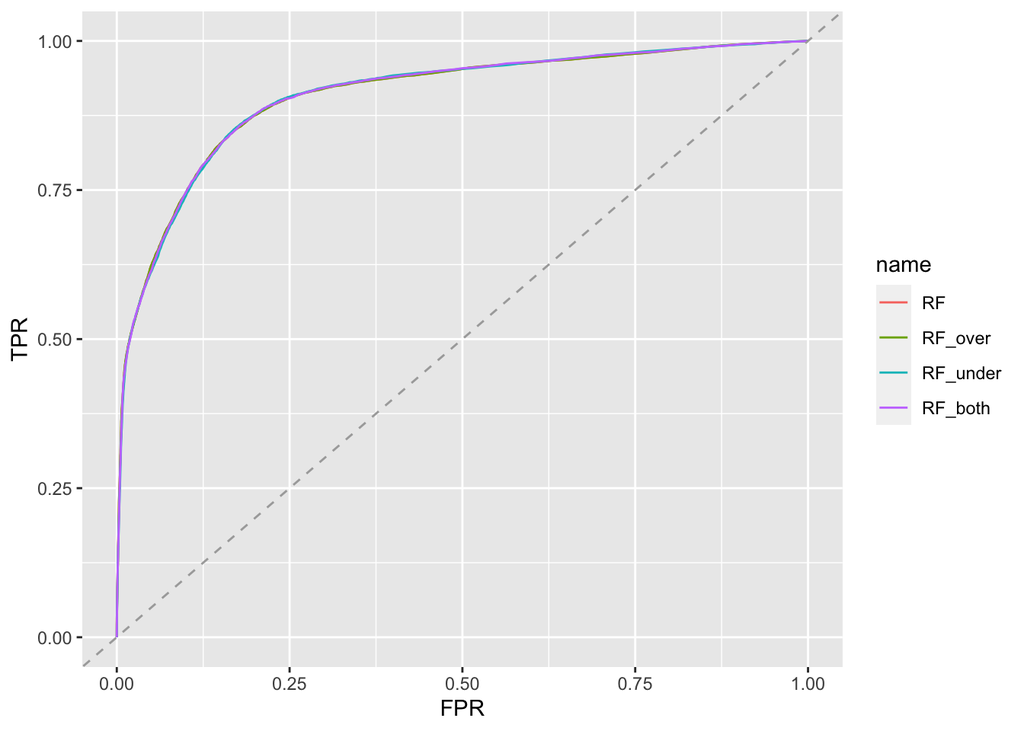

```r
# Plot the ROC curve for Random Forest
ggroc(list(RF = ROC_RF_over, RF_over = ROC_RF_over, RF_under = ROC_RF_under, RF_both = ROC_RF_both), legacy.axes=TRUE)+ xlab("FPR") + ylab("TPR") +
   geom_abline(intercept = 0, slope = 1, color = "darkgrey", linetype = "dashed")
```

```r
# Find ROC
auc(ROC_RFM)
```

```
## Area under the curve: 0.9073
```

```r
auc(ROC_RF_over)
```

```
## Area under the curve: 0.9083
```

```r
auc(ROC_RF_under)
```

```
## Area under the curve: 0.9084
```

```r
auc(ROC_RF_both)
```

```
## Area under the curve: 0.9086
```

### Tuning random forest models

```r
set.seed(1)

# Perform joint hyperparameter tuning using tune function
tuned_rf <- randomForestSRC::tune(Target~., bothsampled,
  mtryStart = sqrt(ncol(bothsampled)),
  nodesizeTry = seq(1, 10, by = 2),
  ntree = 500,
  stepFactor = 1.25, improve = 0.001)

# View the results to see the best hyperparameters
tuned_rf$optimal
```

```
## nodesize     mtry
##        1        3
```

```r
set.seed(1)

bestRF <-  randomForest(Target~., bothsampled, mtry = 4, nodesize = 1)

# Print model_RF
print(bestRF)
```

```
##
## Call:
##  randomForest(formula = Target ~ ., data = bothsampled, mtry = 4,      nodesize = 1)
##                Type of random forest: classification
##                      Number of trees: 500
## No. of variables tried at each split: 4
##
##         OOB estimate of  error rate: 3.46%
## Confusion matrix:
##       0     1 class.error
## 0 88324  4013  0.04346037
## 1  1317 60264  0.02138647
```

```r
# Check the important attributes by using importance() function
importance(bestRF)
```

```
##                     MeanDecreaseGini
## Gender                      825.1360
## Age                        7519.1014
## Dependent                   913.1987
## Marital_Status             1630.4776
## Region_Code                6670.3076
## Years_at_Residence         2473.4673
## Occupation                 2005.9806
## Channel_Code               3537.5893
## Vintage                    7467.1967
## Credit_Product            11415.2206
## Avg_Account_Balance        7117.8201
## Account_Type               1719.6677
## Active                     1038.8163
## Registration              17910.2049
```

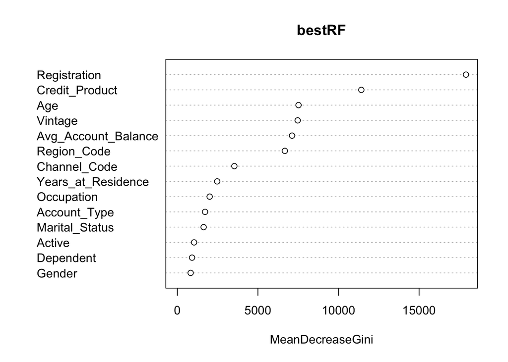

```r
# Plot the importance values
varImpPlot(bestRF)
```

### Evaluation of Random Forest models after tuning models

```r
prediction_RF_best <- predict(bestRF, test_DT)

confusionMatrix(prediction_RF_best, test_DT$Target, positive='1', mode = "prec_recall")
```

```
## Confusion Matrix and Statistics
##
##           Reference
## Prediction     0     1
##          0 51279  2798
##          1  4943  6944
##
##                Accuracy : 0.8826
##                  95% CI : (0.8802, 0.8851)
##     No Information Rate : 0.8523
##     P-Value [Acc > NIR] : < 2.2e-16
##
##                   Kappa : 0.5727
##
##  Mcnemar's Test P-Value : < 2.2e-16
##
##               Precision : 0.5842
##                  Recall : 0.7128
##                      F1 : 0.6421
##              Prevalence : 0.1477
##          Detection Rate : 0.1053
##    Detection Prevalence : 0.1802
##       Balanced Accuracy : 0.8124
##
##        'Positive' Class : 1
##
```

```r
prob_RF_best <- predict(bestRF, test_DT, type = "prob")
```

```r
# Use roc function to return some performance metrics
ROC_RF_best <- roc(test_DT$Target, prob_RF_best[,2])
```

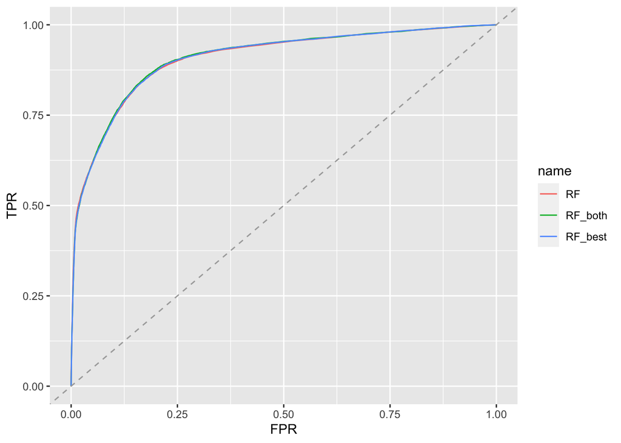

```r
# Plot the ROC curve for Random Forest
ggroc(list(RF = ROC_RFM, RF_both = ROC_RF_both, RF_best = ROC_RF_best), legacy.axes=TRUE) + xlab("FPR") + ylab("TPR") +
   geom_abline(intercept = 0, slope = 1, color = "darkgrey", linetype = "dashed")
```

```r
# Calculate the area under the curve (AUC) for Random Forest
auc(ROC_RF_best)
```

```
## Area under the curve: 0.9076
```

## Building Logistic Regression Models

```r
# Build a logistic regression model assign it to LogReg
LogReg_origin <- glm(Target~. , training_DT, family = "binomial")
LogReg_over <- glm(Target~. , oversampled, family = "binomial")
LogReg_under <- glm(Target~. , undersampled, family = "binomial")
LogReg_both <- glm(Target~. , bothsampled, family = "binomial")
```

```r
# Predict the class probabilities of the test data
LogReg_pred_origin <- predict(LogReg_origin, test_DT, type="response")
LogReg_pred_over <- predict(LogReg_over, test_DT, type="response")
LogReg_pred_under <- predict(LogReg_under, test_DT, type="response")
LogReg_pred_both <- predict(LogReg_both, test_DT, type="response")
```

```r
head(LogReg_pred_origin)
```

```
##          2          4          5          6          8          9
## 0.01852305 0.01490968 0.01523473 0.01292613 0.01994687 0.18880438
```

```r
head(LogReg_pred_over)
```

```
##          2          4          5          6          8          9
## 0.07127897 0.05571030 0.05324924 0.05348188 0.07486287 0.47636408
```

```r
head(LogReg_pred_under)
```

```
##          2          4          5          6          8          9
## 0.06600559 0.05609013 0.05219662 0.05315199 0.07249132 0.47160220
```

```r
head(LogReg_pred_both )
```

```
##          2          4          5          6          8          9
## 0.06448107 0.05858063 0.04927575 0.05038869 0.06978997 0.48401714
```

```r
# Check the levels of target variable
levels(training_DT$Target)
```

```
## [1] "0" "1"
```

```r
levels(oversampled$Target)
```

```
## [1] "0" "1"
```

```r
levels(undersampled$Target)
```

```
## [1] "0" "1"
```

```r
levels(bothsampled$Target)
```

```
## [1] "0" "1"
```

### Evaluation of Logistic Regression Models

```r
# Predict the class
LogReg_class <- ifelse(LogReg_pred_origin > 0.5, 1, 0)
LogReg_class_over <- ifelse(LogReg_pred_over > 0.5, 1, 0)
LogReg_class_under <- ifelse(LogReg_pred_under > 0.5, 1, 0)
LogReg_class_both <- ifelse(LogReg_pred_both > 0.5, 1, 0)
```

```r
# Save the predictions as factor variables
LogReg_class <- as.factor(LogReg_class)
LogReg_class_over <- as.factor(LogReg_class_over)
LogReg_class_under <- as.factor(LogReg_class_under)
LogReg_class_both <- as.factor(LogReg_class_both)
```

```r
confusionMatrix(LogReg_class, test_DT$Target, positive = "1", mode = "prec_recall")
```

```
## Confusion Matrix and Statistics
##
##           Reference
## Prediction     0     1
##          0 55106  5003
##          1  1116  4739
##
##                Accuracy : 0.9072
##                  95% CI : (0.905, 0.9094)
##     No Information Rate : 0.8523
##     P-Value [Acc > NIR] : < 2.2e-16
##
##                   Kappa : 0.5588
##
##  Mcnemar's Test P-Value : < 2.2e-16
##
##               Precision : 0.80939
##                  Recall : 0.48645
##                      F1 : 0.60768
##              Prevalence : 0.14769
##          Detection Rate : 0.07184
##    Detection Prevalence : 0.08876
##       Balanced Accuracy : 0.73330
##
##        'Positive' Class : 1
##
```

```r
confusionMatrix(LogReg_class_over, test_DT$Target, positive = "1", mode = "prec_recall")
```

```
## Confusion Matrix and Statistics
##
##           Reference
## Prediction     0     1
##          0 49141  2361
##          1  7081  7381
##
##                Accuracy : 0.8569
##                  95% CI : (0.8542, 0.8595)
##     No Information Rate : 0.8523
##     P-Value [Acc > NIR] : 0.0004841
##
##                   Kappa : 0.5263
##
##  Mcnemar's Test P-Value : < 2.2e-16
##
##               Precision : 0.5104
##                  Recall : 0.7576
##                      F1 : 0.6099
##              Prevalence : 0.1477
##          Detection Rate : 0.1119
##    Detection Prevalence : 0.2192
##       Balanced Accuracy : 0.8159
##
##        'Positive' Class : 1
##
```

```r
confusionMatrix(LogReg_class_under,test_DT$Target, positive = "1", mode = "prec_recall")
```

```
## Confusion Matrix and Statistics
##
##           Reference
## Prediction     0     1
##          0 49017  2330
##          1  7205  7412
##
##                Accuracy : 0.8555
##                  95% CI : (0.8527, 0.8581)
##     No Information Rate : 0.8523
##     P-Value [Acc > NIR] : 0.01156
##
##                   Kappa : 0.5242
##
##  Mcnemar's Test P-Value : < 2e-16
##
##               Precision : 0.5071
##                  Recall : 0.7608
##                      F1 : 0.6086
##              Prevalence : 0.1477
##          Detection Rate : 0.1124
##    Detection Prevalence : 0.2216
##       Balanced Accuracy : 0.8163
##
##        'Positive' Class : 1
##
```

```r
confusionMatrix(LogReg_class_both ,test_DT$Target, positive = "1", mode = "prec_recall")
```

```
## Confusion Matrix and Statistics
##
##           Reference
## Prediction     0     1
##          0 49031  2342
##          1  7191  7400
##
##                Accuracy : 0.8555
##                  95% CI : (0.8528, 0.8582)
##     No Information Rate : 0.8523
##     P-Value [Acc > NIR] : 0.01091
##
##                   Kappa : 0.5239
##
##  Mcnemar's Test P-Value : < 2e-16
##
##               Precision : 0.5072
##                  Recall : 0.7596
##                      F1 : 0.6082
##              Prevalence : 0.1477
##          Detection Rate : 0.1122
##    Detection Prevalence : 0.2212
##       Balanced Accuracy : 0.8158
##
##        'Positive' Class : 1
##
```

```r
# Logistic Regression
# Obtain the ROC curve data for logistic regression
ROC_LogReg <- roc(test_DT$Target, LogReg_pred_origin)
ROC_LogReg_over <- roc(test_DT$Target, LogReg_pred_over)
ROC_LogReg_under <- roc(test_DT$Target, LogReg_pred_under)
ROC_LogReg_both <- roc(test_DT$Target, LogReg_pred_both)
#Calculate the area under the curve (AUC) for Logistic Regression
auc(ROC_LogReg)
```

```
## Area under the curve: 0.9003
```

```r
auc(ROC_LogReg_over)
```

```
## Area under the curve: 0.9004
```

```r
auc(ROC_LogReg_under)
```

```
## Area under the curve: 0.9005
```

```r
auc(ROC_LogReg_both)
```

```
## Area under the curve: 0.9003
```

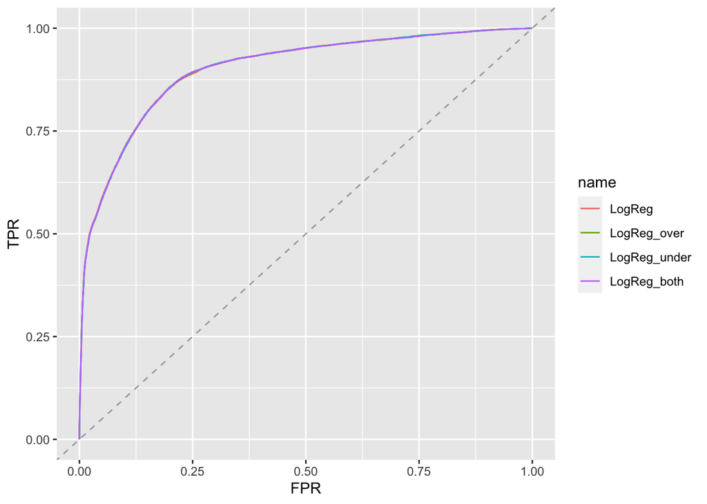

```r
# Plot the ROC curve for Logistic Regression
pROC::ggroc(list(LogReg = ROC_LogReg, LogReg_over = ROC_LogReg_over, LogReg_under = ROC_LogReg_under, LogReg_both = ROC_LogReg_both), legacy.axes=TRUE)+ xlab("FPR") + ylab("TPR") +
   geom_abline(intercept = 0, slope = 1, color = "darkgrey", linetype = "dashed")
```

## Building SVM model

```r
#str(final_ds)
```

```r
#final_ds2 <- final_ds
#trying to encode data
# Apply one hot encoding for categorical variable
#final_ds2 <- one_hot(as.data.table(final_ds2), cols = "Gender")
#final_ds2 <- one_hot(as.data.table(final_ds2), cols = "Region_Code")
#final_ds2 <- one_hot(as.data.table(final_ds2), cols = "Occupation")
#final_ds2 <- one_hot(as.data.table(final_ds2), cols = "Channel_Code")
#final_ds2 <- one_hot(as.data.table(final_ds2), cols = "Credit_Product")
#final_ds2 <- one_hot(as.data.table(final_ds2), cols = "Active")
```

```r
#Apply label encoding to Account_Type
#final_ds2$Account_Type <- recode(final_ds2$Account_Type, "Silver" = 1, "Gold" = 2, "Platinum" = 3)
```

```r
#check str after encoding
#str(final_ds2)
```

```r
#build SVM model
set.seed(123)

model_SVM  <- svm( Target ~. , data =  bothsampled, kernel = "radial", scale = TRUE ,probability = TRUE)
model_SVM_under  <- svm( Target ~. , data =  undersampled, kernel = "radial", scale = TRUE ,probability = TRUE)
model_SVM_origin  <- svm( Target ~. , data =  training_DT, kernel = "radial", scale = TRUE ,probability = TRUE)
```

### Evaluation of SVM Models

```r
# Predict the class of the test data
prediction_SVM <- predict(model_SVM, test_DT)
prediction_SVM_under <- predict(model_SVM_under, test_DT)
prediction_SVM_origin <- predict(model_SVM_origin, test_DT)

# Use confusionMatrix to print the performance of SVM model
confusionMatrix(prediction_SVM, test_DT$Target, positive='1', mode = "prec_recall")
```

```
## Confusion Matrix and Statistics
##
##           Reference
## Prediction     0     1
##          0 48955  2086
##          1  7267  7656
##
##                Accuracy : 0.8582
##                  95% CI : (0.8555, 0.8609)
##     No Information Rate : 0.8523
##     P-Value [Acc > NIR] : 9.093e-06
##
##                   Kappa : 0.5383
##
##  Mcnemar's Test P-Value : < 2.2e-16
##
##               Precision : 0.5130
##                  Recall : 0.7859
##                      F1 : 0.6208
##              Prevalence : 0.1477
##          Detection Rate : 0.1161
##    Detection Prevalence : 0.2262
##       Balanced Accuracy : 0.8283
##
##        'Positive' Class : 1
##
```

```r
confusionMatrix(prediction_SVM_under, test_DT$Target, positive='1', mode = "prec_recall")
```

```
## Confusion Matrix and Statistics
##
##           Reference
## Prediction     0     1
##          0 48802  2104
##          1  7420  7638
##
##                Accuracy : 0.8556
##                  95% CI : (0.8529, 0.8583)
##     No Information Rate : 0.8523
##     P-Value [Acc > NIR] : 0.008355
##
##                   Kappa : 0.532
##
##  Mcnemar's Test P-Value : < 2.2e-16
##
##               Precision : 0.5072
##                  Recall : 0.7840
##                      F1 : 0.6160
##              Prevalence : 0.1477
##          Detection Rate : 0.1158
##    Detection Prevalence : 0.2283
##       Balanced Accuracy : 0.8260
##
##        'Positive' Class : 1
##
```

```r
confusionMatrix(prediction_SVM_origin, test_DT$Target, positive='1', mode = "prec_recall")
```

```
## Confusion Matrix and Statistics
##
##           Reference
## Prediction     0     1
##          0 55358  5117
##          1   864  4625
##
##                Accuracy : 0.9093
##                  95% CI : (0.9071, 0.9115)
##     No Information Rate : 0.8523
##     P-Value [Acc > NIR] : < 2.2e-16
##
##                   Kappa : 0.5605
##
##  Mcnemar's Test P-Value : < 2.2e-16
##
##               Precision : 0.84259
##                  Recall : 0.47475
##                      F1 : 0.60731
##              Prevalence : 0.14769
##          Detection Rate : 0.07011
##    Detection Prevalence : 0.08321
##       Balanced Accuracy : 0.72969
##
##        'Positive' Class : 1
##
```

```r
#focus on precision and recall to evaluate models
```

```r
# Add probability = TRUE for SVM; model_SVM
SVM_pred <- predict(model_SVM, test_DT, probability = TRUE)
SVM_pred_under <- predict(model_SVM_under, test_DT, probability = TRUE)
SVM_pred_origin <- predict(model_SVM_origin, test_DT, probability = TRUE)

# Obtain predicted probabilities for SVM
prob_SVM <- attr(SVM_pred, "probabilities")
prob_SVM_under <- attr(SVM_pred_under, "probabilities")
prob_SVM_origin <- attr(SVM_pred_origin, "probabilities")
```

```r
# Use roc function to return some performance metrics
ROC_SVM <- roc(test_DT$Target, prob_SVM[,2])
ROC_SVM_under <- roc(test_DT$Target, prob_SVM_under[,2])
ROC_SVM_origin <- roc(test_DT$Target, prob_SVM_origin[,2])
```

```r
#Calculate the area under the curve (AUC) for SVM
auc(ROC_SVM)
```

```
## Area under the curve: 0.8981
```

```r
auc(ROC_SVM_under)
```

```
## Area under the curve: 0.8974
```

```r
auc(ROC_SVM_origin)
```

```
## Area under the curve: 0.8969
```

```r
#tuning model
# Find the best cost value among the list (0.1, 1, 10, 100, 1000)
# tune_out = e1071::tune(svm, Target~., data = bothsampled_SVM, kernel= "radial", scale = TRUE, probability = TRUE, ranges = list(cost=c(0.1, 1, 10, 100, 1000)))

# Save the best model as svm_best
# svm_best = tune_out$best.model
# Print svm_model
# Predict the class of the test data
# SVM_tunedpred <- predict(svm_best, test1,probability = TRUE)

# Use confusionMatrix to print the performance of SVM model
# confusionMatrix(SVM_tunedpred, test1$Target, positive='2', mode = "prec_recall")
```

# Models’ Evaluation

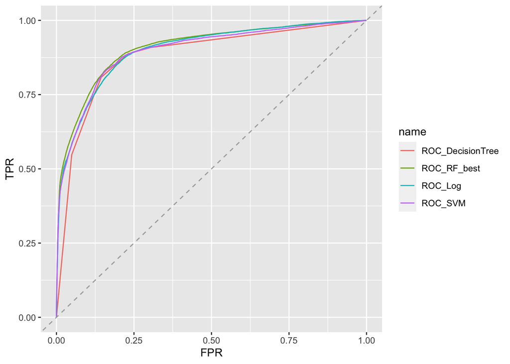

```r
#plot ROC curve for Decision Tree, Random Forest, Logistic Regression
pROC::ggroc(list(ROC_DecisionTree = ROC_DT_both, ROC_RF_best = ROC_RF_best, ROC_Log = ROC_LogReg_both, ROC_SVM = ROC_SVM), legacy.axes=TRUE)+ xlab("FPR") + ylab("TPR") +
   geom_abline(intercept = 0, slope = 1, color = "darkgrey", linetype = "dashed")
```

```r
#AUC
auc(ROC_DT_both)
```

```
## Area under the curve: 0.8815
```

```r
auc(ROC_RF_best)
```

```
## Area under the curve: 0.9076
```

```r
auc(ROC_LogReg_both)
```

```
## Area under the curve: 0.9003
```

```r
auc(ROC_SVM)
```

```
## Area under the curve: 0.8981
```

```r
library(CustomerScoringMetrics)

# Provide probabilities for the outcome of interest and obtain the gain chart data
GainTable_DT <- cumGainsTable(pred.tree.both[,2], test_DT$Target, resolution = 1/100)

GainTable_LogReg <- cumGainsTable(LogReg_pred_both, test_DT$Target, resolution = 1/100)

GainTable_RF <- cumGainsTable(prob_RF_best[,2], test_DT$Target, resolution = 1/100)

GainTable_SVM <- cumGainsTable(prob_SVM[,2], test_DT$Target, resolution = 1/100)
```

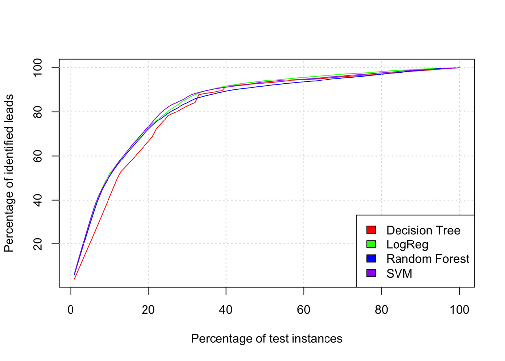

```r
#plot gain chart for Decision Tree, Random Forest, Logistic Regression
plot(GainTable_DT[,4], col="red", type="l",
xlab="Percentage of test instances", ylab="Percentage of identified leads")
lines(GainTable_LogReg[,4], col="green", type ="l")
lines(GainTable_RF[,4], col="blue", type ="l")
lines(GainTable_SVM[,4], col="purple", type ="l")
grid(NULL, lwd = 1)

legend("bottomright",
c("Decision Tree", "LogReg", "Random Forest","SVM"),
fill=c("red","green", "blue","purple"))
```